# *Group* ML 240 - Assignmnent 2 - 17th July 2023

PIMA Indians Diabetes Dataset

Group 240 Kashif Saiyed 2022ac05668@wilp.bits-pilani.ac.in HIMANSHU SAINI 2022ac05736@wilp.bits-pilani.ac.in SINGH SANDEEP ARVIND SARITA <2022ac05665@wilp.bits-pilani.ac.in

Problem Statement The objective of this project is to is to predict whether a patient has diabetes, based on certain diagnostic measurements included in the Pima Indians Diabetes dataset using the machine learning algorithms, Random Forest and k-Nearest Neighbors (KNN). Dataset: diabetes.csv (uploaded as separate file)

1. Import Libraries/Dataset a. Download the dataset. b. Import the required libraries.

```python
## import packages
import pandas as pd
import logging
import os
import io
import matplotlib.pyplot as plt
import seaborn as sns
import numpy as np
from sklearn.preprocessing import StandardScaler
from sklearn.ensemble import RandomForestClassifier
from sklearn.model_selection import train_test_split
from sklearn.model_selection import KFold
from sklearn.linear_model import LogisticRegression
from sklearn.preprocessing import PowerTransformer
from sklearn.impute import SimpleImputer
from scipy.stats import boxcox, yeojohnson
from sklearn.utils import resample
from sklearn.neighbors import KNeighborsClassifier
from sklearn.model_selection import GridSearchCV
from sklearn.metrics import accuracy_score
from sklearn.metrics import classification_report, accuracy_score, precision_score, recall_score, f1_score
```

```python
## File Path
file_path = r'C:\Users\admin\Documents\GitHub\bits-coursework\ML\Assignments\Assignment 2.6 - Data\Assignment 2.6 - Data\diabetes.csv'
```

```python
# Configure logging
logging.basicConfig(level=logging.INFO, format='%(asctime)s - %(levelname)s - %(message)s')
```

```python
# Create function to load data and log metadata, summary of the input

def load_data(file_path):
    """
    Load data from the specified file path using pandas.

    Parameters:
    file_path (str): The path to the CSV file.

    Returns:
    pd.DataFrame: The loaded DataFrame.
    """
    try:
        # Load the data into a DataFrame
        data = pd.read_csv(file_path)

        # Display headers
        logging.info("Headers: %s", data.columns.tolist())

        # Log information
        log_info(data)

        return data
    except FileNotFoundError:
        logging.error("Error: File not found.")
        return None
    except pd.errors.ParserError:
        logging.error("Error: Unable to parse the file.")
        return None

def log_info(data):
    """
    Log information about the dataset.

    Parameters:
    data (pd.DataFrame): The DataFrame.

    Returns:
    None
    """
    # Log basic information
    logging.info("Dataset information:")
    logging.info("Number of rows: %d", data.shape[0])
    logging.info("Number of columns: %d", data.shape[1])
    logging.info("Size of dataset: %d", data.size)

    # Log data types
    logging.info("Data types:")
    logging.info(data.dtypes)

    # Log sample data
    logging.info("Sample data:\n%s", data.head())
```

```python
# Load data using the function created
data = load_data(file_path)
```

```
2023-09-17 19:26:58,008 - INFO - Headers: ['Pregnancies', 'Glucose', 'BloodPressure', 'SkinThickness', 'Insulin', 'BMI', 'DiabetesPedigreeFunction', 'Age', 'Outcome']
2023-09-17 19:26:58,009 - INFO - Dataset information:
2023-09-17 19:26:58,010 - INFO - Number of rows: 768
2023-09-17 19:26:58,012 - INFO - Number of columns: 9
2023-09-17 19:26:58,015 - INFO - Size of dataset: 6912
2023-09-17 19:26:58,017 - INFO - Data types:
2023-09-17 19:26:58,018 - INFO - Pregnancies                   int64
Glucose                       int64
BloodPressure                 int64
SkinThickness                 int64
Insulin                       int64
BMI                         float64
DiabetesPedigreeFunction    float64
Age                           int64
Outcome                       int64
dtype: object
2023-09-17 19:26:58,021 - INFO - Sample data:
   Pregnancies  Glucose  BloodPressure  SkinThickness  Insulin   BMI  \
0            6      148             72             35        0  33.6
1            1       85             66             29        0  26.6
2            8      183             64              0        0  23.3
3            1       89             66             23       94  28.1
4            0      137             40             35      168  43.1

   DiabetesPedigreeFunction  Age  Outcome
0                     0.627   50        1
1                     0.351   31        0
2                     0.672   32        1
3                     0.167   21        0
4                     2.288   33        1
```

1. Data Visualization and Exploration [1M] a. Print 2 rows for sanity check to identify all the features present in the dataset and if the target matches with them. b. Comment on class imbalance with appropriate visualization method. c. Provide appropriate data visualizations to get an insight about the dataset. d. Do the correlational analysis on the dataset. Provide a visualization for the same. Will this correlational analysis have effect on feature selection that you will perform in the next step? Justify your answer. Answer without justification will not be awarded marks.

```python
# a. Printing two rows
def print_sample_rows(data, num_rows=2):
    """
    Print a specified number of sample rows for data exploration.

    Parameters:
    data (pd.DataFrame): The DataFrame.
    num_rows (int): Number of rows to display.

    Returns:
    None
    """
    print(f"\nSample {num_rows} rows:")
    print(data.head(num_rows))

# Print 2 sample rows for sanity check
print_sample_rows(data, num_rows=2)
```

```
Sample 2 rows:
   Pregnancies  Glucose  BloodPressure  SkinThickness  Insulin   BMI  \
0            6      148             72             35        0  33.6
1            1       85             66             29        0  26.6

   DiabetesPedigreeFunction  Age  Outcome
0                     0.627   50        1
1                     0.351   31        0
```

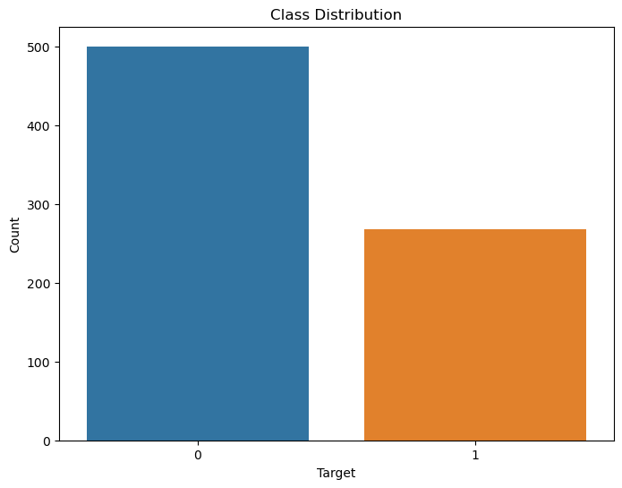

```python
# b. Comment on Class imbalance
def plot_class_distribution(data, target_column):
    """
    Plot the class distribution using a count plot.

    Parameters:
    data (pd.DataFrame): The DataFrame.
    target_column (str): The name of the target column.

    Returns:
    None
    """
    plt.figure(figsize=(8, 6))
    sns.countplot(x=target_column, data=data)
    plt.xlabel('Target')
    plt.ylabel('Count')
    plt.title('Class Distribution')
    plt.show()

# Example usage, assuming 'target' is the name of the target column
plot_class_distribution(data, target_column='Outcome')
```

```python
# c. Visualizatons & Exploration of the data

## Summary table
def generate_summary_table(data):
    """
    Generate a summary table with statistics for each feature.

    Parameters:
    data (pd.DataFrame): The DataFrame.

    Returns:
    pd.DataFrame: Summary table.
    """
    summary_table = data.describe().transpose()
    summary_table['missing_values'] = data.isnull().sum()
    summary_table['unique_values'] = data.nunique()
    summary_table['mean'] = data.mean()
    summary_table['median'] = data.median()
    summary_table['mode'] = data.mode().iloc[0]  # Mode can have multiple values, taking the first mode
    return summary_table

# Example usage
summary_table = generate_summary_table(data)
print("Summary Table:")
print(summary_table)
```

```
Summary Table:
                          count        mean         std     min       25%  \
Pregnancies               768.0    3.845052    3.369578   0.000   1.00000
Glucose                   768.0  120.894531   31.972618   0.000  99.00000
BloodPressure             768.0   69.105469   19.355807   0.000  62.00000
SkinThickness             768.0   20.536458   15.952218   0.000   0.00000
Insulin                   768.0   79.799479  115.244002   0.000   0.00000
BMI                       768.0   31.992578    7.884160   0.000  27.30000
DiabetesPedigreeFunction  768.0    0.471876    0.331329   0.078   0.24375
Age                       768.0   33.240885   11.760232  21.000  24.00000
Outcome                   768.0    0.348958    0.476951   0.000   0.00000

                               50%        75%     max  missing_values  \
Pregnancies                 3.0000    6.00000   17.00               0
Glucose                   117.0000  140.25000  199.00               0
BloodPressure              72.0000   80.00000  122.00               0
SkinThickness              23.0000   32.00000   99.00               0
Insulin                    30.5000  127.25000  846.00               0
BMI                        32.0000   36.60000   67.10               0
DiabetesPedigreeFunction    0.3725    0.62625    2.42               0
Age                        29.0000   41.00000   81.00               0
Outcome                     0.0000    1.00000    1.00               0

                          unique_values    median    mode
Pregnancies                          17    3.0000   1.000
Glucose                             136  117.0000  99.000
BloodPressure                        47   72.0000  70.000
SkinThickness                        51   23.0000   0.000
Insulin                             186   30.5000   0.000
BMI                                 248   32.0000  32.000
DiabetesPedigreeFunction            517    0.3725   0.254
Age                                  52   29.0000  22.000
Outcome                               2    0.0000   0.000
```

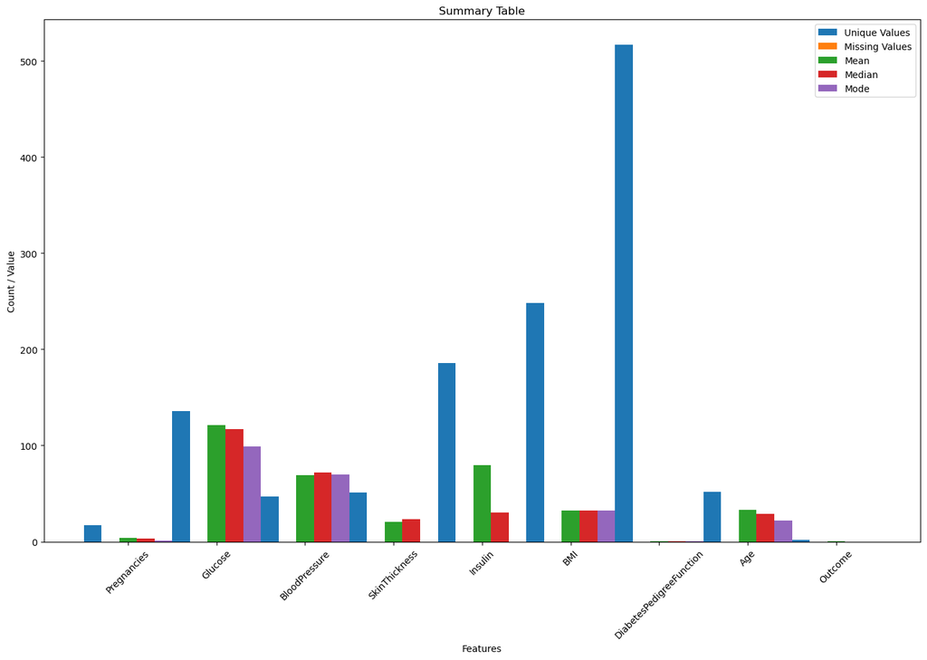

```python
## Generate data summary plots
def plot_summary_table(summary_table):
    """
    Plot the summary table using a bar plot.

    Parameters:
    summary_table (pd.DataFrame): The summary table.

    Returns:
    None
    """
    # Plotting the unique values, missing values, mean, median, and mode for each feature
    x = np.arange(len(summary_table))
    width = 0.2

    fig, ax = plt.subplots(figsize=(14, 10))
    ax.bar(x - 2*width, summary_table['unique_values'], width, label='Unique Values')
    ax.bar(x - width, summary_table['missing_values'], width, label='Missing Values')
    ax.bar(x, summary_table['mean'], width, label='Mean')
    ax.bar(x + width, summary_table['median'], width, label='Median')
    ax.bar(x + 2*width, summary_table['mode'], width, label='Mode')

    ax.set_xlabel('Features')
    ax.set_ylabel('Count / Value')
    ax.set_title('Summary Table')
    ax.set_xticks(x)
    ax.set_xticklabels(summary_table.index)
    ax.legend()

    plt.xticks(rotation=45)
    plt.tight_layout()
    plt.show()

# Example usage
plot_summary_table(summary_table)
```

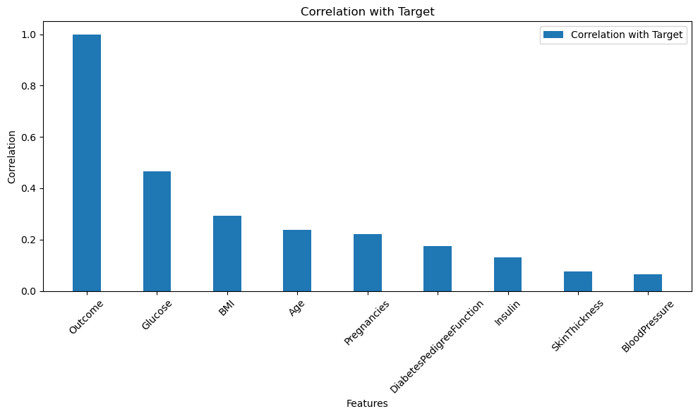

```python
# Correlation plots with the target
def plot_correlation_with_target(correlation_with_target):
    """
    Plot the correlation of features with the target using a bar plot.

    Parameters:
    correlation_with_target (pd.DataFrame): Correlation statistics with the target.

    Returns:
    None
    """
    x = np.arange(len(correlation_with_target))
    width = 0.4

    fig, ax = plt.subplots(figsize=(10, 6))
    ax.bar(x, correlation_with_target['Outcome'], width, label='Correlation with Target')

    ax.set_xlabel('Features')
    ax.set_ylabel('Correlation')
    ax.set_title('Correlation with Target')
    ax.set_xticks(x)
    ax.set_xticklabels(correlation_with_target.index)
    ax.legend()

    plt.xticks(rotation=45)
    plt.tight_layout()
    plt.show()

# Example usage
plot_correlation_with_target(correlation_with_target)
```

[output not shown]

Comments: Seems that Glucoses followed by BMI are most correlated with Outcome.

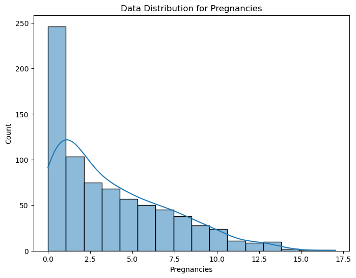

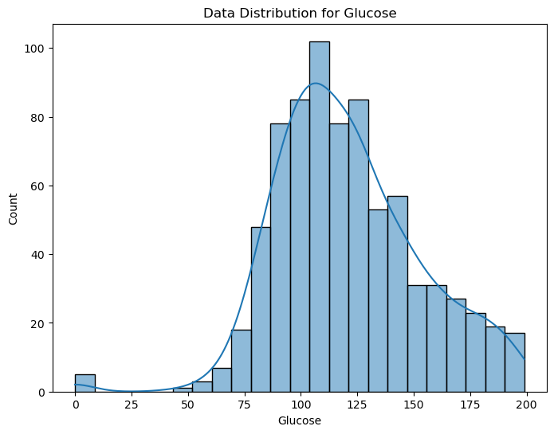

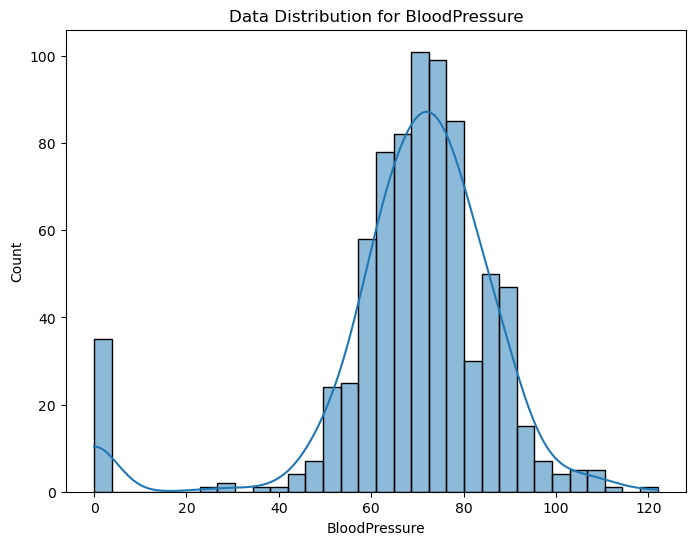

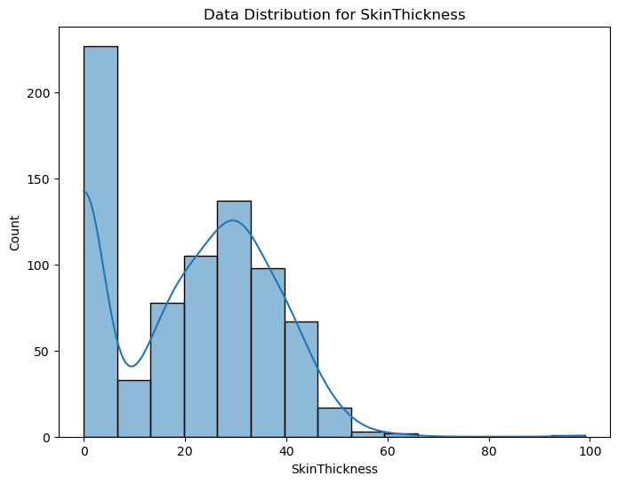

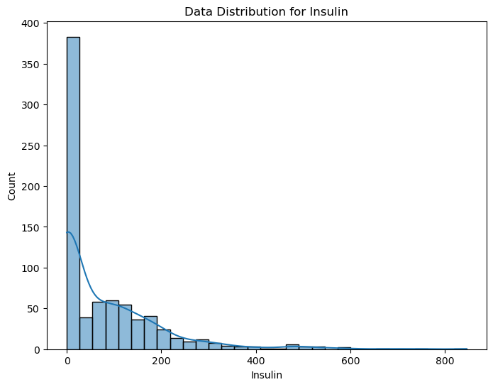

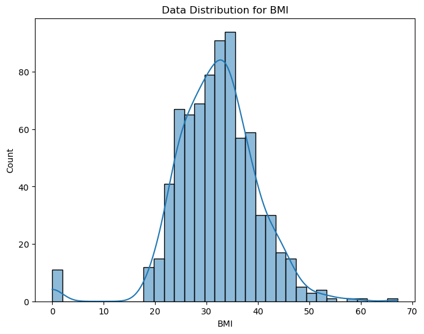

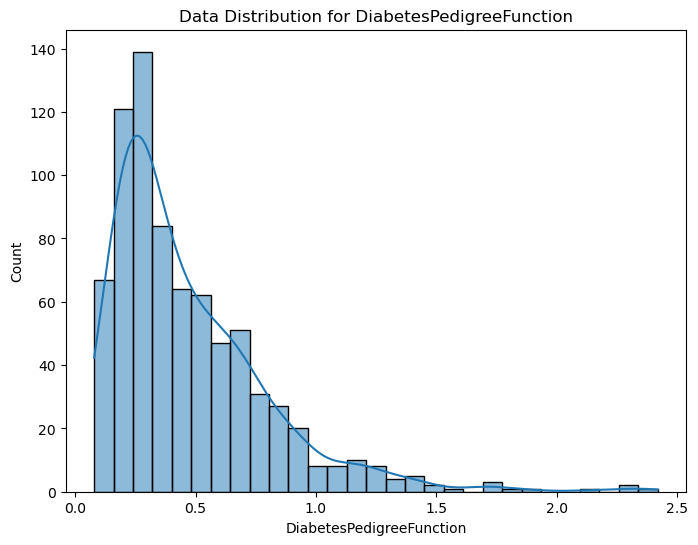

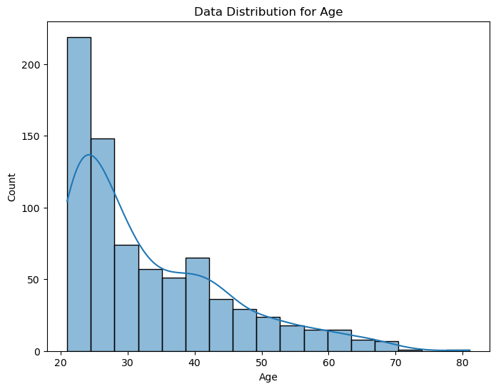

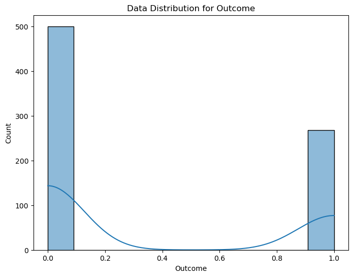

```python
# Data Distribution Graphs for Each Feature
def plot_data_distributions(data):
    """
    Plot data distribution graphs for each feature.

    Parameters:
    data (pd.DataFrame): The DataFrame.

    Returns:
    None
    """
    for column in data.columns:
        plt.figure(figsize=(8, 6))
        sns.histplot(data[column], kde=True)
        plt.xlabel(column)
        plt.ylabel('Count')
        plt.title(f'Data Distribution for {column}')
        plt.show()

# Example usage
plot_data_distributions(data)
```

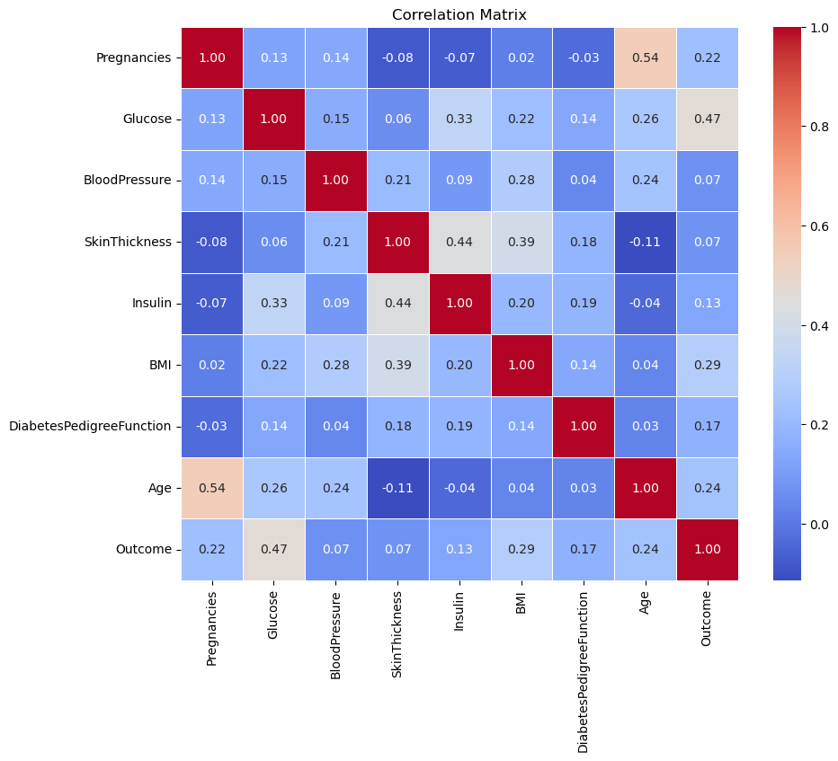

```python
# d. Do the correlational analysis on the dataset and provide a visualization for the same.

def plot_correlation_heatmap(data):
    """
    Plot a heatmap to visualize the correlation matrix.

    Parameters:
    data (pd.DataFrame): The DataFrame.

    Returns:
    None
    """
    correlation_matrix = data.corr()
    plt.figure(figsize=(10, 8))
    sns.heatmap(correlation_matrix, annot=True, cmap='coolwarm', fmt='.2f', linewidths=0.5)
    plt.title('Correlation Matrix')
    plt.show()

# Assuming all columns in the dataset are used for correlation analysis
plot_correlation_heatmap(data)
```

Comments: As we notice, highest correlation of Outcome is with Glucodse (0.47), and the least correlation is with Blood pressure and Skin Thickness.

1. Data Pre-processing and cleaning [2M] a. Do the appropriate pre-processing of the data like identifying NULL or Missing Values if any, handling of outliers if present in the dataset, skewed data etc. Mention the pre-processing steps performed in the markdown cell. Explore few latest data balancing tasks and its effect on model evaluation parameters. b. Apply appropriate feature engineering techniques for them. Apply the feature transformation techniques like Standardization, Normalization, etc. You are free to apply the appropriate transformations depending upon the structure and the complexity of your dataset. Provide proper justification. Techniques used without justification will not be awarded marks. Explore a few techniques for identifying feature importance for your feature engineering task.

```python
# 3a. Data Pre-processing and Cleaning

## Find misssing values

## Data analyser for missing values class
class DataAnalyzer:
    """
    A class for performing basic data analysis operations.
    """

    def __init__(self, data_frame):
        """
        Initialize the DataAnalyzer instance with a pandas DataFrame.

        Parameters:
        - data_frame (pd.DataFrame): A DataFrame containing the data.
        """
        self.data_frame = data_frame

    def check_missing_values(self):
        """
        Check for missing values in each feature column.

        Returns:
        - dict: A dictionary where keys are column names and values are the count of missing values.
        """
        missing_counts = self.data_frame.isnull().sum()
        return missing_counts.to_dict()

    def identify_outliers_zscore(self, threshold=3):
        """
        Identify outliers using the Z-score method.

        Parameters:
        - threshold (float): The threshold for identifying outliers. Default is 3.

        Returns:
        - dict: A dictionary where keys are column names and values are a dictionary containing outlier information.
        """
        outlier_info = {}
        for column in self.data_frame.columns:
            z_scores = np.abs((self.data_frame[column] - self.data_frame[column].mean()) / self.data_frame[column].std())
            outliers = np.where(z_scores > threshold)[0]
            if len(outliers) > 0:
                outlier_info[column] = {
                    'count': len(outliers),
                    'mean_z_score': np.mean(z_scores),
                    'outlier_indices': outliers.tolist()
                }
        return outlier_info

    def plot_outliers_scatter(self, outliers_info):
        """
        Plot outliers for each feature using a scatter plot.

        Parameters:
        - outliers_info (dict): A dictionary containing outlier information for each feature.

        Returns:
        None
        """
        for feature, info in outliers_info.items():
            plt.figure(figsize=(8, 6))
            plt.scatter(range(len(self.data_frame[feature])), self.data_frame[feature], c='blue', label='Data Points')
            plt.scatter(info['outlier_indices'], self.data_frame[feature].iloc[info['outlier_indices']], c='red', label='Outliers')
            plt.xlabel('Index')
            plt.ylabel(feature)
            plt.title(f'Outliers for {feature}')
            plt.legend()
            plt.show()
    def impute_outliers_with_median(self, outliers_info):
        """
        Impute outliers with the median for each feature.

        Parameters:
        - outliers_info (dict): A dictionary containing outlier information for each feature.

        Returns:
        - pd.DataFrame: DataFrame with outliers imputed using the median.
        """
        data_imputed = self.data_frame.copy()

        for feature, info in outliers_info.items():
            outlier_indices = info['outlier_indices']
            median_value = data_imputed[feature].median()
            data_imputed.loc[outlier_indices, feature] = median_value

        return data_imputed


# Example usage
analyzer = DataAnalyzer(data)
missing_values = analyzer.check_missing_values()
print("Missing Values:")
print(missing_values)

outliers_info = analyzer.identify_outliers_zscore()
print("\nOutliers (Z-score method) Summary:")
for feature, info in outliers_info.items():
    print(f"\nFeature: {feature}")
    print(f"Count of Outliers: {info['count']}")
    print(f"Mean Z-score: {info['mean_z_score']:.2f}")
    print(f"Outlier Indices: {info['outlier_indices']}")
```

```
Missing Values:
{'Pregnancies': 0, 'Glucose': 0, 'BloodPressure': 0, 'SkinThickness': 0, 'Insulin': 0, 'BMI': 0, 'DiabetesPedigreeFunction': 0, 'Age': 0, 'Outcome': 0}

Outliers (Z-score method) Summary:

Feature: Pregnancies
Count of Outliers: 4
Mean Z-score: 0.82
Outlier Indices: [88, 159, 298, 455]

Feature: Glucose
Count of Outliers: 5
Mean Z-score: 0.79
Outlier Indices: [75, 182, 342, 349, 502]

Feature: BloodPressure
Count of Outliers: 35
Mean Z-score: 0.65
Outlier Indices: [7, 15, 49, 60, 78, 81, 172, 193, 222, 261, 266, 269, 300, 332, 336, 347, 357, 426, 430, 435, 453, 468, 484, 494, 522, 533, 535, 589, 601, 604, 619, 643, 697, 703, 706]

Feature: SkinThickness
Count of Outliers: 1
Mean Z-score: 0.86
Outlier Indices: [579]

Feature: Insulin
Count of Outliers: 18
Mean Z-score: 0.73
Outlier Indices: [8, 13, 111, 153, 186, 220, 228, 247, 286, 370, 409, 415, 486, 584, 645, 655, 695, 753]

Feature: BMI
Count of Outliers: 14
Mean Z-score: 0.74
Outlier Indices: [9, 49, 60, 81, 145, 177, 371, 426, 445, 494, 522, 673, 684, 706]

Feature: DiabetesPedigreeFunction
Count of Outliers: 11
Mean Z-score: 0.75
Outlier Indices: [4, 45, 58, 228, 330, 370, 371, 395, 445, 593, 621]

Feature: Age
Count of Outliers: 5
Mean Z-score: 0.82
Outlier Indices: [123, 453, 459, 666, 684]
```

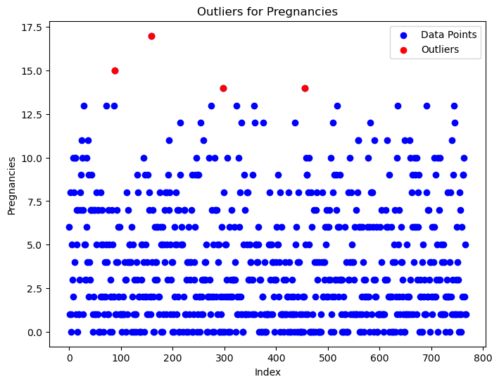

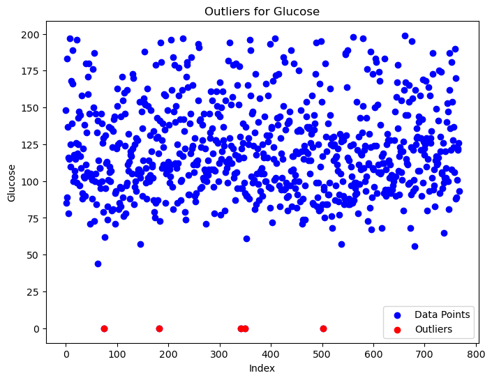

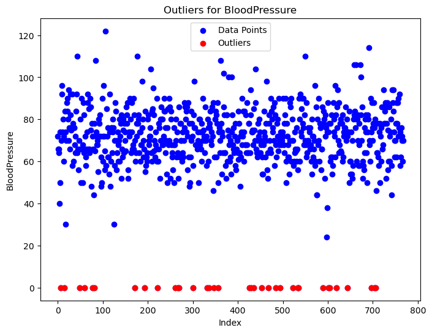

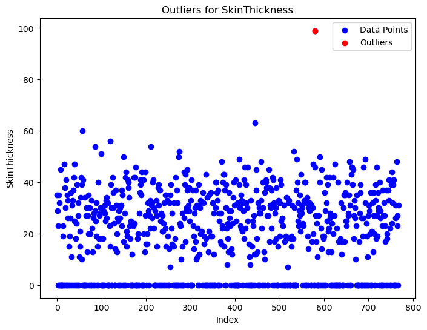

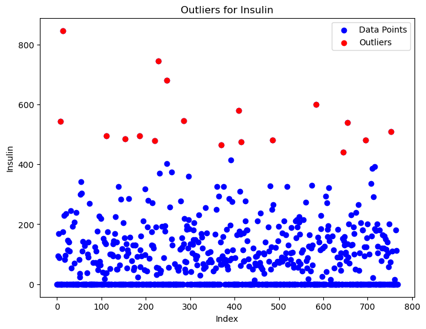

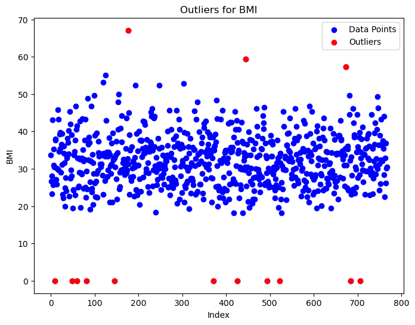

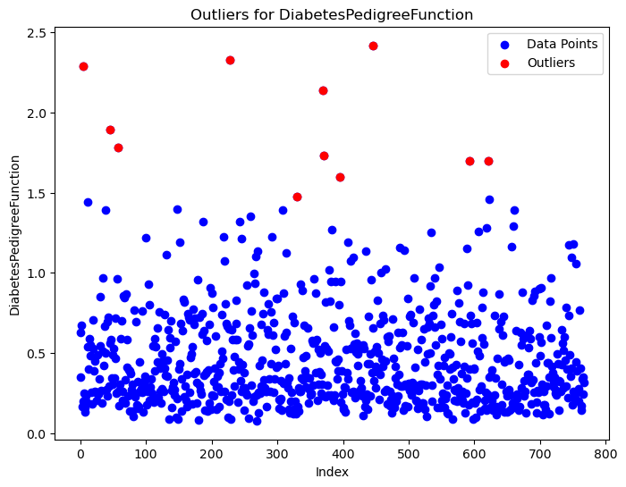

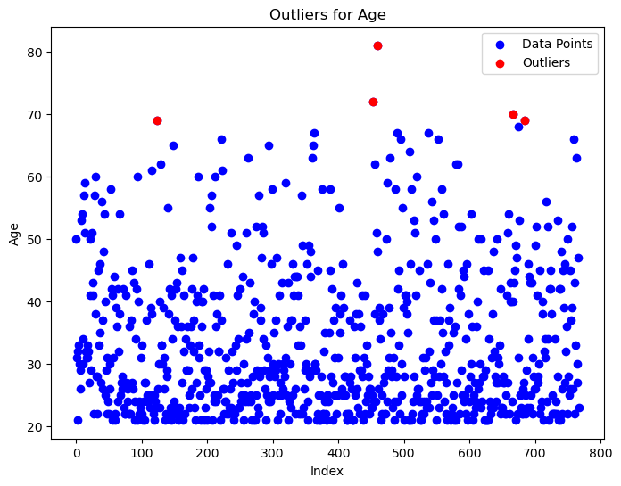

```python
## plot outliers
analyzer = DataAnalyzer(data)
outliers_info = analyzer.identify_outliers_zscore()

# Plot outliers for each feature using scatter plot
analyzer.plot_outliers_scatter(outliers_info)
```

Comments: For each feature, the outliers identifed using the Z score method have been visualized above. Now we can apply some imputation logic to deal with the outliers

```python
## Imputing and correcting outliers
# Impute outliers with median
analyzer = DataAnalyzer(data)
data_imputed_median = analyzer.impute_outliers_with_median(outliers_info)
print("Data after imputing outliers with median:")
print(data_imputed_median.head())
```

```
Data after imputing outliers with median:
   Pregnancies  Glucose  BloodPressure  SkinThickness  Insulin   BMI  \
0            6      148             72             35      0.0  33.6
1            1       85             66             29      0.0  26.6
2            8      183             64              0      0.0  23.3
3            1       89             66             23     94.0  28.1
4            0      137             40             35    168.0  43.1

   DiabetesPedigreeFunction  Age  Outcome
0                    0.6270   50        1
1                    0.3510   31        0
2                    0.6720   32        1
3                    0.1670   21        0
4                    0.3725   33        1
```

Comments: In the plot above, it seems that there are features that have zeros as values, but they don't make sense. For example, Skin thickness, Insulin cannot be 0 for anyone. There we should impute this data to something in order to remove these strange values.

```python
## Impute features with zero  values with median

def impute_zeros_with_median(data, features):
    """
    Impute zero values in specified features with the median.

    Parameters:
    - data (pd.DataFrame): The DataFrame containing the data.
    - features (list): A list of feature names to impute zero values.

    Returns:
    - pd.DataFrame: DataFrame with zero values in specified features imputed with the median.
    """
    data_imputed = data.copy()

    for feature in features:
        median_value = data_imputed[feature].median()
        data_imputed[feature] = np.where(data_imputed[feature] == 0, median_value, data_imputed[feature])

    return data_imputed

# Example usage
# Assume 'data' is your DataFrame and 'features_to_impute' is a list of feature names to be imputed
features_to_impute = ['Glucose', 'Insulin', 'SkinThickness', 'BloodPressure']
data_imputed = impute_zeros_with_median(data_imputed_median, features_to_impute)

print("Data after zero imputation with median:")
print(data_imputed.head())
```

```
Data after zero imputation with median:
   Pregnancies  Glucose  BloodPressure  SkinThickness  Insulin   BMI  \
0            6    148.0           72.0           35.0    29.75  33.6
1            1     85.0           66.0           29.0    29.75  26.6
2            8    183.0           64.0           23.0    29.75  23.3
3            1     89.0           66.0           23.0    94.00  28.1
4            0    137.0           40.0           35.0   168.00  43.1

   DiabetesPedigreeFunction  Age  Outcome
0                    0.6270   50        1
1                    0.3510   31        0
2                    0.6720   32        1
3                    0.1670   21        0
4                    0.3725   33        1
```

Comments: Using the above function, we have corrected the outliers with median of the distribution for the feature. Using median is safer, as it will be more stable in skewed distributions.

```python
# Handling Skewed Data using Log transformatoin
def apply_skew_correction(data, features):
    """
    Apply skewness correction (log transformation) for specified features in the DataFrame.

    Parameters:
    - data (pd.DataFrame): The DataFrame containing the data.
    - features (list): A list of feature names to be corrected.

    Returns:
    - pd.DataFrame: DataFrame with the specified features corrected for skewness.
    """
    data_corrected = data.copy()
    data_corrected[features] = np.log1p(data_corrected[features])
    return data_corrected

# Example usage
# Assume 'data' is your DataFrame and 'features_to_correct' is a list of feature names to be corrected
features_to_correct = ['Age', 'DiabetesPedigreeFunction']
data_corrected = apply_skew_correction(data_imputed, features_to_correct)
print("Data after skewness correction:")
print(data_corrected.head())
```

```
Data after skewness correction:
   Pregnancies  Glucose  BloodPressure  SkinThickness  Insulin   BMI  \
0            6    148.0           72.0           35.0    29.75  33.6
1            1     85.0           66.0           29.0    29.75  26.6
2            8    183.0           64.0           23.0    29.75  23.3
3            1     89.0           66.0           23.0    94.00  28.1
4            0    137.0           40.0           35.0   168.00  43.1

   DiabetesPedigreeFunction       Age  Outcome
0                  0.486738  3.931826        1
1                  0.300845  3.465736        0
2                  0.514021  3.496508        1
3                  0.154436  3.091042        0
4                  0.316634  3.526361        1
```

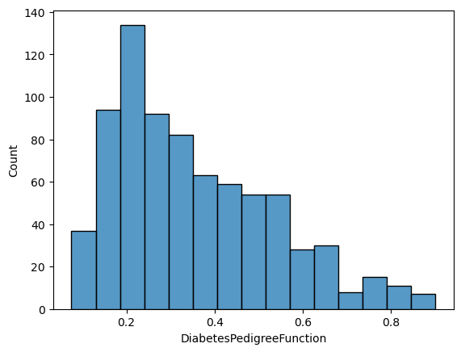

```python
sns.histplot(data_corrected['DiabetesPedigreeFunction'])
```

Comments: We observed earlier, that Age, DiabetesPedigressFunction were skewed. So above we applied log transformation to the data. But it seems the data is still skewed as seen above. So we will apply a different transformation technique and check again.

```python
## Apply skew correction

def apply_skew_correction(data, features, method='boxcox'):
    """
    Apply skewness correction for specified features in the DataFrame.

    Parameters:
    - data (pd.DataFrame): The DataFrame containing the data.
    - features (list): A list of feature names to be corrected.
    - method (str): The transformation method: 'boxcox' or 'yeojohnson'.

    Returns:
    - pd.DataFrame: DataFrame with the specified features corrected for skewness.
    """
    data_corrected = data.copy()

    for feature in features:
        if method == 'boxcox':
            transformed, _ = boxcox(data_corrected[feature] + 1)  # Adding 1 to handle zero values
        elif method == 'yeojohnson':
            transformed, _ = yeojohnson(data_corrected[feature] + 1)  # Adding 1 to handle zero values
        else:
            raise ValueError("Invalid method. Choose 'boxcox' or 'yeojohnson'.")

        data_corrected[feature] = transformed

    return data_corrected

# Example usage

features_to_correct = ['Age', 'DiabetesPedigreeFunction']
data_corrected_boxcox = apply_skew_correction(data_imputed_median, features_to_correct, method='boxcox')

features_to_correct = ['Age', 'DiabetesPedigreeFunction']
data_corrected_yeojohnson = apply_skew_correction(data_imputed_median, features_to_correct, method='yeojohnson')
```

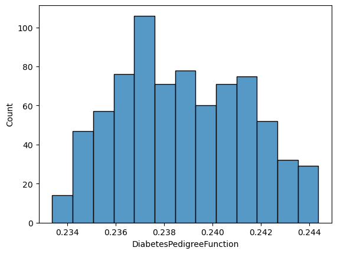

```python
sns.histplot(data_corrected_yeojohnson['DiabetesPedigreeFunction'])
```

Comments: As observed with a YeoJohnson transformation, it's working better to normalise the data and remove skewness. So we will use this one.

```python
## Normalization the continuous data columns

def apply_standardization(data, exclude_cols):
    """
    Apply standardization to specified columns in the DataFrame.

    Parameters:
    - data (pd.DataFrame): The DataFrame containing the data.
    - exclude_cols (list): A list of column names to exclude from standardization.

    Returns:
    - pd.DataFrame: DataFrame with specified columns standardized.
    """
    data_standardized = data.copy()

    # Exclude the specified columns from standardization
    cols_to_standardize = [col for col in data.columns if col not in exclude_cols]

    # Apply standardization
    scaler = StandardScaler()
    data_standardized[cols_to_standardize] = scaler.fit_transform(data[cols_to_standardize])

    return data_standardized

# Example usage
# Assume 'data' is your DataFrame and 'exclude_columns' is a list of column names to exclude
exclude_columns = ['Outcome', 'Pregnancies']  # Exclude outcome and label columns
data_standardized = apply_standardization(data_corrected_yeojohnson, exclude_columns)

print("Data after standardization:")
print(data_standardized.head())
```

```
Data after standardization:
   Pregnancies   Glucose  BloodPressure  SkinThickness   Insulin       BMI  \
0            6  0.866045      -0.031990       0.928238 -0.767974  0.190718
1            1 -1.205066      -0.528319       0.545788 -0.767974 -0.865966
2            8  2.016662      -0.693761      -1.302720 -0.767974 -1.364117
3            1 -1.073567      -0.528319       0.163338  0.299113 -0.639534
4            0  0.504422      -2.679076       0.928238  1.139161  1.624789

   DiabetesPedigreeFunction       Age  Outcome
0                  0.884043  1.396598        1
1                 -0.162924  0.139915        0
2                  1.006524  0.245126        1
3                 -1.295342 -1.482203        0
4                 -0.058182  0.343735        1
```

Comments: We have applied standardization of data to all the features except the outcome and the non continuous features above. There is no need to apply normalizatoin as we don't need to keep the values between 0 & 1 necessarily.

```
Important Features:
                    Feature  Importance
1                   Glucose    0.275775
5                       BMI    0.168011
7                       Age    0.132212
6  DiabetesPedigreeFunction    0.126667
2             BloodPressure    0.086371
0               Pregnancies    0.080234
3             SkinThickness    0.066796
4                   Insulin    0.063934
```

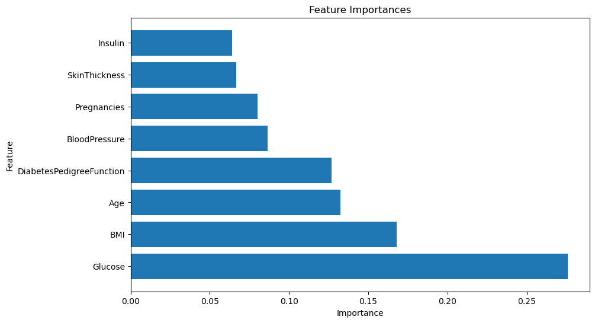

```python
## Explore the feature importance

def identify_important_features(data, target_column):
    """
    Identify important features using a Random Forest classifier.

    Parameters:
    - data (pd.DataFrame): The DataFrame containing the data.
    - target_column (str): The name of the target column.

    Returns:
    - pd.DataFrame: DataFrame with feature importances.
    """
    X = data.drop(target_column, axis=1)
    y = data[target_column]

    # Initialize a Random Forest classifier
    rf_classifier = RandomForestClassifier(random_state=42)

    # Fit the classifier to the data
    rf_classifier.fit(X, y)

    # Get feature importances
    feature_importances = pd.DataFrame({
        'Feature': X.columns,
        'Importance': rf_classifier.feature_importances_
    })

    # Sort features by importance
    feature_importances = feature_importances.sort_values(by='Importance', ascending=False)

    return feature_importances

# Example usage
# Assume 'data' is your DataFrame and 'target_column' is the name of the target column
target_column = 'Outcome'  # Replace with your target column name
important_features = identify_important_features(data_standardized, target_column)

print("Important Features:")
print(important_features)

# Plot feature importances
plt.figure(figsize=(10, 6))
plt.barh(important_features['Feature'], important_features['Importance'])
plt.xlabel('Importance')
plt.ylabel('Feature')
plt.title('Feature Importances')
plt.show()
```

Comments: As expected, we observe that Glucose is the most important feature to predict Diabetes. This feature importance was created using a randomforest classifier.

1. Model Building [5M] a. Split the dataset into training and test sets. Answer without justification will not be awarded marks. [1M] i. Train = 80 % Test = 20% ii. Also, try to split the dataset with different ratios of your choice. b. Build a Random Forest classification model to predict the diabetic condition. [2M] i. Tune hyperparameters (e.g., number of trees, maximum depth) using crossvalidation. Justify your answer. ii. Evaluate the model's performance using appropriate metrics. c. Build a KNN classification model to predict the diabetic condition. [2M] i. Determine the optimal value of k through hyperparameter tuning and crossvalidation. Justify your answer. ii. Evaluate the KNN model's performance using appropriate metrics.

```python
# Split data between test & train

# Assuming 'data_standardized' contains the preprocessed data
X = data_standardized.drop('Outcome', axis=1)  # Features
y = data_standardized['Outcome']  # Target variable

# Splitting the data into train and test sets
X_train, X_test, y_train, y_test = train_test_split(X, y, test_size=0.2, random_state=42)

# Print the shape of train and test sets
print("Train set shape:", X_train.shape, y_train.shape)
print("Test set shape:", X_test.shape, y_test.shape)
```

```
Train set shape: (614, 8) (614,)
Test set shape: (154, 8) (154,)
```

Comments: We can use the above test size, to try different test set sizes. For now we will continue with 20% test size

```python
## Tune RandomForest Classifier

# Initialize the classifier
rf_classifier = RandomForestClassifier(random_state=42)

# Define the hyperparameters to tune
param_grid = {
    'n_estimators': [50, 100, 150],  # Number of trees
    'max_depth': [None, 10, 20, 30]  # Maximum depth of the trees
}

# Initialize GridSearchCV
grid_search = GridSearchCV(rf_classifier, param_grid, cv=5, scoring='accuracy')

# Fit the model
grid_search.fit(X_train, y_train)

# Print the best parameters
print("Best Hyperparameters:", grid_search.best_params_)

# Evaluate the model on the test set
best_rf_classifier = grid_search.best_estimator_
y_pred_rf = best_rf_classifier.predict(X_test)

# Evaluate using appropriate metrics (e.g., accuracy)
accuracy_rf = accuracy_score(y_test, y_pred_rf)
print("Accuracy of Random Forest:", accuracy_rf)
```

```
Best Hyperparameters: {'max_depth': None, 'n_estimators': 50}
Accuracy of Random Forest: 0.7532467532467533
```

Comments: We observe that max_depth as None, and number of tress as 50 are the best hyperparameters for this Randomforest model. Accuracy was used to evaluate the model, which is of 75%

```python
## Building KNN model

# Initialize the classifier
knn_classifier = KNeighborsClassifier()

# Define the hyperparameters to tune
param_grid_knn = {
    'n_neighbors': [3, 5, 7, 9]  # Number of neighbors (k)
}

# Initialize GridSearchCV for KNN
grid_search_knn = GridSearchCV(knn_classifier, param_grid_knn, cv=5, scoring='accuracy')

# Fit the model
grid_search_knn.fit(X_train, y_train)

# Print the best parameters
print("Best Hyperparameters for KNN:", grid_search_knn.best_params_)

# Evaluate the model on the test set
best_knn_classifier = grid_search_knn.best_estimator_
y_pred_knn = best_knn_classifier.predict(X_test)

# Evaluate using appropriate metrics (e.g., accuracy)
accuracy_knn = accuracy_score(y_test, y_pred_knn)
print("Accuracy of KNN:", accuracy_knn)
```

```
Best Hyperparameters for KNN: {'n_neighbors': 5}
Accuracy of KNN: 0.6558441558441559
```

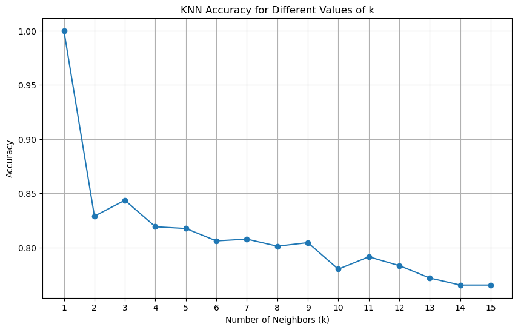

```python
def plot_knn_accuracy(X_train, y_train, max_k=10):
    """
    Plot the accuracy of KNN for different values of k using the elbow method.

    Parameters:
    - X_train (pd.DataFrame): Features of the training set.
    - y_train (pd.Series): Target variable of the training set.
    - max_k (int): Maximum value of k to consider.

    Returns:
    None
    """
    k_values = range(1, max_k + 1)
    accuracies = []

    for k in k_values:
        knn_classifier = KNeighborsClassifier(n_neighbors=k)
        knn_classifier.fit(X_train, y_train)
        y_pred = knn_classifier.predict(X_train)
        accuracy = accuracy_score(y_train, y_pred)
        accuracies.append(accuracy)

    # Plotting the accuracy
    plt.figure(figsize=(10, 6))
    plt.plot(k_values, accuracies, marker='o')
    plt.xlabel('Number of Neighbors (k)')
    plt.ylabel('Accuracy')
    plt.title('KNN Accuracy for Different Values of k')
    plt.xticks(k_values)
    plt.grid(True)
    plt.show()

# Example usage
# Assuming 'X_train' and 'y_train' are the features and target for training
plot_knn_accuracy(X_train, y_train, max_k=15)
```

1. Performance Evaluation [2M] a. Compare the performance of the Random Forest and KNN models using appropriate evaluation metrics. b. Provide insights into which model performs better and why. Answer without justification will not be awarded marks

```python
## Compare performance of the 2 models
# Assuming best_rf_classifier and best_knn_classifier are the best models after hyperparameter tuning

# Evaluate Random Forest (RF) model
y_pred_rf = best_rf_classifier.predict(X_test)

accuracy_rf = accuracy_score(y_test, y_pred_rf)
precision_rf = precision_score(y_test, y_pred_rf)
recall_rf = recall_score(y_test, y_pred_rf)
f1_rf = f1_score(y_test, y_pred_rf)

print("Random Forest Metrics:")
print("Accuracy:", accuracy_rf)
print("Precision:", precision_rf)
print("Recall:", recall_rf)
print("F1 Score:", f1_rf)

# Evaluate K-Nearest Neighbors (KNN) model
y_pred_knn = best_knn_classifier.predict(X_test)

accuracy_knn = accuracy_score(y_test, y_pred_knn)
precision_knn = precision_score(y_test, y_pred_knn)
recall_knn = recall_score(y_test, y_pred_knn)
f1_knn = f1_score(y_test, y_pred_knn)

print("\nK-Nearest Neighbors Metrics:")
print("Accuracy:", accuracy_knn)
print("Precision:", precision_knn)
print("Recall:", recall_knn)
print("F1 Score:", f1_knn)
```

```
Random Forest Metrics:
Accuracy: 0.7532467532467533
Precision: 0.6491228070175439
Recall: 0.6727272727272727
F1 Score: 0.6607142857142858

K-Nearest Neighbors Metrics:
Accuracy: 0.6558441558441559
Precision: 0.5192307692307693
Recall: 0.4909090909090909
F1 Score: 0.5046728971962617
```

Comments: As observed above, with taking the 2 best models with optimised Hyperparamters and evaluated on test data, the RandomForest is better than the KNN, in terms of all the 4 metrics - Accuracy, Precision, Recall, F1 Score.

Accuracy: Formula: (TP + TN) / (TP + TN + FP + FN) Accuracy measures the proportion of correctly predicted instances (both true positives and true negatives) out of the total instances. It provides an overall assessment of the model's performance.

Precision: Formula: TP / (TP + FP) Precision measures the proportion of correctly predicted positive instances (true positives) out of all instances predicted as positive. It's a measure of the accuracy of the positive predictions.

Recall (Sensitivity or True Positive Rate): Formula: TP / (TP + FN) Recall measures the proportion of correctly predicted positive instances (true positives) out of all actual positive instances. It's a measure of how well the model identifies actual positives.

F1 Score: Formula: 2 *(Precision* Recall) / (Precision + Recall) The F1 score is the harmonic mean of precision and recall. It balances precision and recall, providing a single metric that considers both false positives and false negatives. It is a useful metric when we want to balance false positives and false negatives.

Comments: Comparison of the two models - Random Forest generally outperforms K-Nearest Neighbors in terms of all metrics: accuracy, precision, recall, and F1 score. Random Forest has a higher accuracy, precision, recall, and F1 score compared to K-Nearest Neighbors. The higher precision and recall of Random Forest suggest that it not only predicts more accurately but also identifies more true positives compared to KNN.

Conclusion: Therefore, based on these metrics, Random Forest is the better-performing model for this dataset. Furthermore, we can use cross validation, more feature engineering, data imputation techniques to further improve this model performance.